# **Lab 6: Convolutional Neural Networks**

### Authors: Will Lahners, Edward Powers, and Nino Castellano

Our machine learning project presents a compelling business case, leveraging a comprehensive dataset comprising cars and motorcycles. The rationale behind this initiative is to cater to the pressing needs of law enforcement agencies, state departments of transportation, and similar entities, all of which rely heavily on efficient vehicle identification systems. By leveraging advanced algorithms, our software will empower police stations to expedite investigations, identify stolen vehicles, and enforce traffic regulations with greater precision. Similarly, state departments of transportation can streamline processes related to vehicle registration, licensing, and compliance, thereby reducing administrative burdens and enhancing overall operational efficiency. By offering a sophisticated solution tailored to the specific needs of these agencies, we not only create value for them but also contribute to the broader goal of promoting road safety and effective law enforcement practices. Hence, our machine learning project represents a strategic investment with far-reaching benefits for both public safety and administrative effectiveness.

## **Describing the Data**

Dataset: https://www.kaggle.com/datasets/utkarshsaxenadn/car-vs-bike-classification-dataset/data

## Preparation (3 points total)

```python
import os
import pandas as pd
from sklearn.preprocessing import LabelEncoder
import cv2
import numpy as np
import matplotlib.pyplot as plt

data = {'path': [], 'label': []}

# Define the root path of our dataset
root_path = "Car-Bike-Dataset"

# Get the subfolders (Car and Bike)
folders = os.listdir(root_path)
for folder in folders:
    folder_path = os.path.join(root_path, folder)
    files = os.listdir(folder_path)
    for file in files:
        file_path = os.path.join(folder_path, file)
        data['path'].append(file_path)
        data['label'].append(folder)

# Create a Pandas DataFrame
df = pd.DataFrame(data)

# Encode labels using LabelEncoder (Car: 0, Bike: 1)
le = LabelEncoder()
df['class'] = le.fit_transform(df['label'])

# Shuffle the DataFrame
shuffled_df = df.sample(frac=1, random_state=42).reset_index(drop=True)

# Define image size for resizing
h, w = 100, 100

# Create a list to store resized and grayscaled images
table_data = []

# Iterate through each image
for i, row in shuffled_df.iterrows():
    img_path = row['path']
    img = cv2.imread(img_path)
    res_img = cv2.resize(img, dsize=(h, w))
    gray_img = cv2.cvtColor(res_img, cv2.COLOR_BGR2GRAY)
    gray_img_with_channel = np.expand_dims(gray_img, axis=-1)
    table_data.append(gray_img_with_channel)

# Convert the image data to a NumPy array
X = np.array(table_data)
y = shuffled_df['class']
labels = shuffled_df['label']

# Code credit to us
```

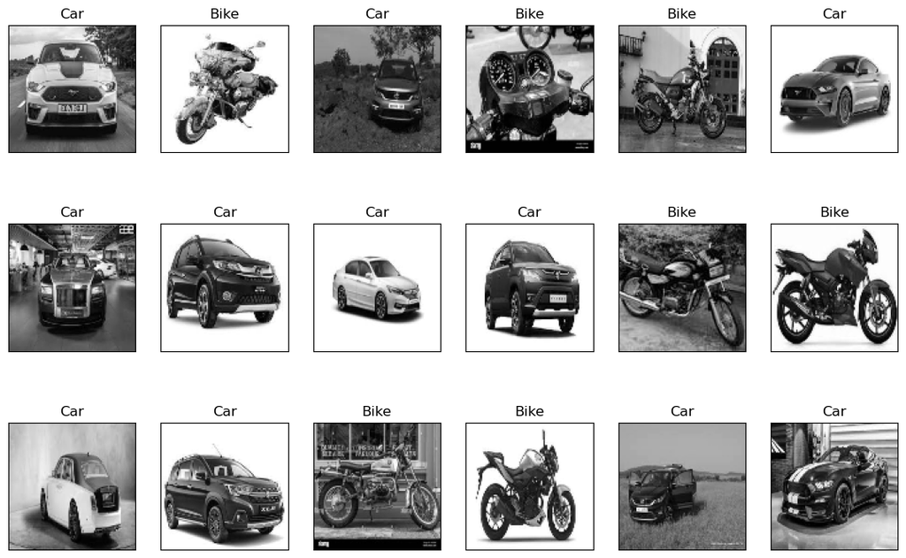

```python
def plot_gallery(images, titles, h, w, n_row=3, n_col=6):
    """Helper function to plot a gallery of images"""
    plt.figure(figsize=(1.8 * n_col, 2.4 * n_row))
    plt.subplots_adjust(bottom=0, left=.01, right=.99, top=.90, hspace=.35)
    for i in range(n_row * n_col):
        plt.subplot(n_row, n_col, i + 1)
        plt.imshow(images[i].reshape((h, w)), cmap=plt.cm.gray)
        plt.title(titles[i], size=12)
        plt.xticks(())
        plt.yticks(())

plot_gallery(X, labels, h, w)

# Code credit to us
```

> [1.5 points] Choose and explain what metric(s) you will use to evaluate your algorithm’s performance. You should give a detailed argument for why this (these) metric(s) are appropriate on your data. That is, why is the metric appropriate for the task (e.g., in terms of the business case for the task). Please note: rarely is accuracy the best evaluation metric to use. Think deeply about an appropriate measure of performance.

We will go with the **F1-Score** as our metric.

In this scenario, both precision and recall are important: Precision: We want to ensure that when the model identifies a vehicle as a car, it is indeed a car. Misclassifying a bike as a car could lead to incorrect traffic light timing or inaccurate traffic flow analysis. Recall: We also want to ensure that the model correctly identifies most cars. Missing cars could lead to underestimation of traffic volume and congestion, impacting traffic management decisions. The F1-score balances precision and recall, making it a suitable choice when both aspects are crucial. It provides a single score that reflects the overall accuracy and robustness of the model.

> [1.5 points] Choose the method you will use for dividing your data into training and testing (i.e., are you using Stratified 10-fold cross validation? Shuffle splits? Why?). Explain why your chosen method is appropriate or use more than one method as appropriate. Convince me that your cross validation method is a realistic mirroring of how an algorithm would be used in practice.

A stratified K-fold cross-validation with K=10 offers a robust and realistic approach to evaluating the performance of our car vs. bike classification model. It ensures that the model is tested on diverse data, reflects the real-world scenario of encountering a continuous stream of images, and mitigates potential biases due to class imbalances.

```python
from sklearn.model_selection import StratifiedKFold
import tensorflow as tf

# Define the number of folds and batch size
k = 10
batch_size = 128

# Create a StratifiedKFold object
skfold = StratifiedKFold(n_splits=k, shuffle=True, random_state=42)

# Lists to store the datasets for each fold
train_datasets = []
test_datasets = []

# Create datasets for each fold
for train_index, test_index in skfold.split(X, y):
    # Split data into training and testing sets
    X_train, X_test = X[train_index], X[test_index]
    y_train, y_test = y[train_index], y[test_index]

    # Create TensorFlow datasets
    ds_train = tf.data.Dataset.from_tensor_slices((X_train, y_train))
    ds_train = ds_train.batch(batch_size).prefetch(batch_size)
    train_datasets.append(ds_train)

    ds_test = tf.data.Dataset.from_tensor_slices((X_test, y_test))
    ds_test = ds_test.batch(batch_size).prefetch(batch_size)
    test_datasets.append(ds_test)

# Code credit to Gemini API and us
```

[output not shown]

## Modeling (6 points total)

> [1.5 points] Setup the training to use data expansion in Keras (also called data augmentation). Explain why the chosen data expansion techniques are appropriate for your dataset. You should make use of Keras augmentation layers, like in the class examples.

> [2 points] Create a convolutional neural network to use on your data using Keras. Investigate at least two different convolutional network architectures and investigate changing one or more parameters of each architecture such as the number of filters. This means, at a minimum, you will train a total of four models (2 different architectures, with 2 parameters changed in each architecture). Use the method of train/test splitting and evaluation metric that you argued for at the beginning of the lab. Visualize the performance of the training and validation sets per iteration (use the "history" parameter of Keras). Be sure that models converge.

**Architecture 1: Baseline CNN**

**Architecture 2: ResNet**

```python
import tensorflow as tf
from tensorflow.keras.models import Sequential
from tensorflow.keras.layers import Conv2D, MaxPooling2D, Flatten, Dense, Dropout
from tensorflow.keras.layers import RandomFlip, RandomRotation, RandomZoom, RandomContrast

# Define the model
model1a = Sequential()

# Data Augmentation Layers
model1a.add(RandomFlip("horizontal"))
model1a.add(RandomRotation(0.1))
model1a.add(RandomZoom(0.1))
model1a.add(RandomContrast(0.1))

# Convolutional Layers
model1a.add(Conv2D(32, (3, 3), activation="relu", input_shape=(h, w, 1)))
model1a.add(MaxPooling2D((2, 2)))
model1a.add(Conv2D(64, (3, 3), activation="relu"))
model1a.add(MaxPooling2D((2, 2)))

# Classification Layers
model1a.add(Flatten())
model1a.add(Dense(128, activation="relu"))
model1a.add(Dropout(0.5))
model1a.add(Dense(1, activation="sigmoid"))  # Output layer

# Compile the model
model1a.compile(loss="binary_crossentropy", optimizer="adam", metrics=["accuracy", tf.keras.metrics.Precision(), tf.keras.metrics.Recall(), tf.keras.metrics.AUC()])

# Code credit to Gemini API and us
```

```python
# Lists to store metrics for each fold
model1a_fold_f1_scores = []
model1a_fold_histories = []

epochs = 10

# Iterate through the folds
for fold, (ds_train, ds_test) in enumerate(zip(train_datasets, test_datasets)):
    # Train the model
    print(f"Training for Fold {fold+1}")
    history = model1a.fit(ds_train, epochs=epochs, validation_data=ds_test, verbose=1)

    # Evaluate on the test set
    _, accuracy, precision, recall, auc = model1a.evaluate(ds_test, verbose=0)
    f1_score = 2 * (precision * recall) / (precision + recall)
    model1a_fold_f1_scores.append(f1_score)
    model1a_fold_histories.append(history)

# Code credit to Gemini API and us
```

```
Training for Fold 1
```

[output not shown]

[output not shown]

```
Training for Fold 2
```

[output not shown]

[output not shown]

```
Training for Fold 3
```

[output not shown]

[output not shown]

```
Training for Fold 4
```

[output not shown]

[output not shown]

```
Training for Fold 5
```

[output not shown]

[output not shown]

```
Training for Fold 6
```

[output not shown]

[output not shown]

```
Training for Fold 7
```

[output not shown]

[output not shown]

```
Training for Fold 8
```

[output not shown]

[output not shown]

```
Training for Fold 9
```

[output not shown]

[output not shown]

```
Training for Fold 10
```

[output not shown]

[output not shown]

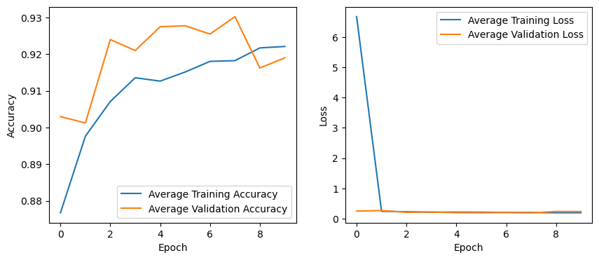

```python
# Calculate average accuracy and loss across folds
avg_accuracy = np.mean([h.history['accuracy'] for h in model1a_fold_histories], axis=0)
avg_val_accuracy = np.mean([h.history['val_accuracy'] for h in model1a_fold_histories], axis=0)
avg_loss = np.mean([h.history['loss'] for h in model1a_fold_histories], axis=0)
avg_val_loss = np.mean([h.history['val_loss'] for h in model1a_fold_histories], axis=0)

# Plot the average curves
plt.figure(figsize=(10, 4))
plt.subplot(1, 2, 1)
plt.plot(avg_accuracy, label='Average Training Accuracy')
plt.plot(avg_val_accuracy, label='Average Validation Accuracy')
plt.xlabel('Epoch')
plt.ylabel('Accuracy')
plt.legend()

plt.subplot(1, 2, 2)
plt.plot(avg_loss, label='Average Training Loss')
plt.plot(avg_val_loss, label='Average Validation Loss')
plt.xlabel('Epoch')
plt.ylabel('Loss')
plt.legend()
plt.show()

# Code credit to us
```

### **Model 1B:** (3, 3) kernel size, 64 filters each

```python
# Define the model
model1b = Sequential()

# Data Augmentation Layers
model1b.add(RandomFlip("horizontal"))
model1b.add(RandomRotation(0.1))
model1b.add(RandomZoom(0.1))
model1b.add(RandomContrast(0.1))

# Convolutional Layers
model1b.add(Conv2D(64, (3, 3), activation="relu", input_shape=(h, w, 1))) # using 64 rather than 32 filters for this model
model1b.add(MaxPooling2D((2, 2)))
model1b.add(Conv2D(64, (3, 3), activation="relu"))
model1b.add(MaxPooling2D((2, 2)))

# Classification Layers
model1b.add(Flatten())
model1b.add(Dense(128, activation="relu"))
model1b.add(Dropout(0.5))
model1b.add(Dense(1, activation="sigmoid"))  # Output layer

# Compile the model
model1b.compile(loss="binary_crossentropy", optimizer="adam", metrics=["accuracy", tf.keras.metrics.Precision(), tf.keras.metrics.Recall(), tf.keras.metrics.AUC()])

# Code credit to Gemini API and us
```

Below took 234m 48.1s on 2070 SUPER

```python
# Lists to store metrics for each fold
model1b_fold_f1_scores = []
model1b_fold_histories = []

# Iterate through the folds
for fold, (ds_train, ds_test) in enumerate(zip(train_datasets, test_datasets)):
    # Train the model
    print(f"Training for Fold {fold+1}")
    history = model1b.fit(ds_train, epochs=epochs, validation_data=ds_test, verbose=1)

    # Evaluate on the test set
    _, accuracy, precision, recall, auc = model1b.evaluate(ds_test, verbose=0)
    f1_score = 2 * (precision * recall) / (precision + recall)
    model1b_fold_f1_scores.append(f1_score)
    model1b_fold_histories.append(history)

# Code credit to Gemini API and us
```

```
Training for Fold 1
Training for Fold 2
Training for Fold 3
Training for Fold 4
Training for Fold 5
Training for Fold 6
Training for Fold 7
Training for Fold 8
Training for Fold 9
Training for Fold 10
```

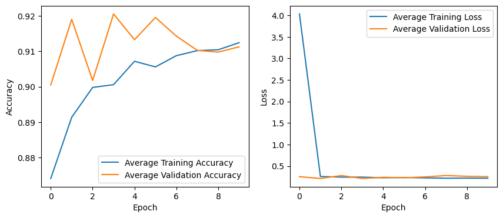

```python
# Calculate average accuracy and loss across folds
avg_accuracy = np.mean([h.history['accuracy'] for h in model1b_fold_histories], axis=0)
avg_val_accuracy = np.mean([h.history['val_accuracy'] for h in model1b_fold_histories], axis=0)
avg_loss = np.mean([h.history['loss'] for h in model1b_fold_histories], axis=0)
avg_val_loss = np.mean([h.history['val_loss'] for h in model1b_fold_histories], axis=0)

# Plot the average curves
plt.figure(figsize=(10, 4))
plt.subplot(1, 2, 1)
plt.plot(avg_accuracy, label='Average Training Accuracy')
plt.plot(avg_val_accuracy, label='Average Validation Accuracy')
plt.xlabel('Epoch')
plt.ylabel('Accuracy')
plt.legend()

plt.subplot(1, 2, 2)
plt.plot(avg_loss, label='Average Training Loss')
plt.plot(avg_val_loss, label='Average Validation Loss')
plt.xlabel('Epoch')
plt.ylabel('Loss')
plt.legend()
plt.show()

# Code credit to us
```

### **Model 2A:** ResNet with 2 residual blocks

```python
import tensorflow as tf
from tensorflow.keras.models import Model
from tensorflow.keras.layers import (Input, Conv2D, MaxPooling2D, Add,
                                     Activation, Flatten, Dense, Dropout,
                                     RandomFlip, RandomRotation, RandomZoom, RandomContrast)

# Define input shape and hyperparameters
h, w, l = 100, 100, 1  # Image dimensions and channels (grayscale)
filters_initial = 32
filters_residual = 64

# Define the input layer
input_layer = Input(shape=(h, w, l))

# Data Augmentation
x = RandomFlip("horizontal")(input_layer)
x = RandomRotation(0.1)(x)
x = RandomZoom(0.1)(x)
x = RandomContrast(0.1)(x)

# Initial Convolutional Layer
x = Conv2D(filters_residual, (3, 3), padding="same", activation="relu")(x)  # Use 64 filters
x = MaxPooling2D((2, 2))(x)

# Residual Block 1
shortcut1 = x  # Save the input to the residual block
x = Conv2D(filters_residual, (3, 3), padding="same", activation="relu")(x)
x = Conv2D(filters_residual, (3, 3), padding="same")(x)
x = Add()([x, shortcut1])  # Add the residual connection
x = Activation("relu")(x)

# Residual Block 2
shortcut2 = x
x = Conv2D(filters_residual, (3, 3), padding="same", activation="relu")(x)
x = Conv2D(filters_residual, (3, 3), padding="same")(x)
x = Add()([x, shortcut2])
x = Activation("relu")(x)

# Classification Layers
x = MaxPooling2D((2, 2))(x)
x = Flatten()(x)
x = Dropout(0.25)(x)
x = Dense(256, activation="relu")(x)
x = Dropout(0.5)(x)
output_layer = Dense(1, activation="sigmoid")(x)

# Create the ResNet model
model2A = Model(inputs=input_layer, outputs=output_layer)

# Compile the model
model2A.compile(loss="binary_crossentropy", optimizer="adam",
                 metrics=["accuracy", tf.keras.metrics.Precision(), tf.keras.metrics.Recall(), tf.keras.metrics.AUC()])

# Code credit to Gemini API and us
```

Below took 238m 39.2s on 2070 SUPER

```python
# Lists to store metrics for each fold
model2A_fold_f1_scores = []
model2A_fold_histories = []

# Number of epochs (adjust as needed)
epochs = 10

# Iterate through the folds
for fold, (ds_train, ds_test) in enumerate(zip(train_datasets, test_datasets)):
    # Train the model
    print(f"Training for Fold {fold+1}")
    history = model2A.fit(ds_train, epochs=epochs, validation_data=ds_test, verbose=1)

    # Evaluate on the test set
    _, accuracy, precision, recall, auc = model2A.evaluate(ds_test, verbose=0)
    f1_score = 2 * (precision * recall) / (precision + recall)
    model2A_fold_f1_scores.append(f1_score)
    model2A_fold_histories.append(history)

# Code credit to Gemini API and us
```

```
Training for Fold 1
Training for Fold 2
Training for Fold 3
Training for Fold 4
Training for Fold 5
Training for Fold 6
Training for Fold 7
Training for Fold 8
Training for Fold 9
Training for Fold 10
```

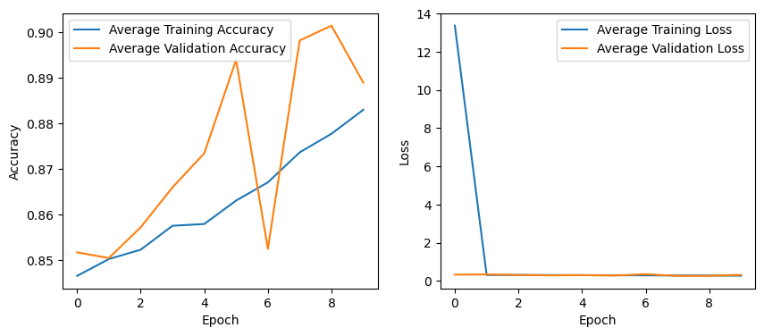

```python
# Calculate average accuracy and loss across folds
avg_accuracy = np.mean([h.history['accuracy'] for h in model2A_fold_histories], axis=0)
avg_val_accuracy = np.mean([h.history['val_accuracy'] for h in model2A_fold_histories], axis=0)
avg_loss = np.mean([h.history['loss'] for h in model2A_fold_histories], axis=0)
avg_val_loss = np.mean([h.history['val_loss'] for h in model2A_fold_histories], axis=0)

# Plot the average curves
plt.figure(figsize=(10, 4))
plt.subplot(1, 2, 1)
plt.plot(avg_accuracy, label='Average Training Accuracy')
plt.plot(avg_val_accuracy, label='Average Validation Accuracy')
plt.xlabel('Epoch')
plt.ylabel('Accuracy')
plt.legend()

plt.subplot(1, 2, 2)
plt.plot(avg_loss, label='Average Training Loss')
plt.plot(avg_val_loss, label='Average Validation Loss')
plt.xlabel('Epoch')
plt.ylabel('Loss')
plt.legend()
plt.show()

# Code credit to us
```

### **Model 2B:** ResNet with 3 residual blocks

```python
import tensorflow as tf
from tensorflow.keras.models import Model
from tensorflow.keras.layers import (Input, Conv2D, MaxPooling2D, Add,
                                     Activation, Flatten, Dense, Dropout,
                                     RandomFlip, RandomRotation, RandomZoom, RandomContrast)

# Define input shape and hyperparameters
h, w, l = 100, 100, 1  # Image dimensions and channels (grayscale)
filters_initial = 32
filters_residual = 64

# Define the input layer
input_layer = Input(shape=(h, w, l))

# Data Augmentation
x = RandomFlip("horizontal")(input_layer)
x = RandomRotation(0.1)(x)
x = RandomZoom(0.1)(x)
x = RandomContrast(0.1)(x)

# Initial Convolutional Layer
x = Conv2D(filters_residual, (3, 3), padding="same", activation="relu")(x)  # Use 64 filters
x = MaxPooling2D((2, 2))(x)

# Residual Block 1
shortcut1 = x  # Save the input to the residual block
x = Conv2D(filters_residual, (3, 3), padding="same", activation="relu")(x)
x = Conv2D(filters_residual, (3, 3), padding="same")(x)
x = Add()([x, shortcut1])  # Add the residual connection
x = Activation("relu")(x)

# Residual Block 2
shortcut2 = x
x = Conv2D(filters_residual, (3, 3), padding="same", activation="relu")(x)
x = Conv2D(filters_residual, (3, 3), padding="same")(x)
x = Add()([x, shortcut2])
x = Activation("relu")(x)

# *** Additional Residual Block 3 ***
shortcut3 = x
x = Conv2D(filters_residual, (3, 3), padding="same", activation="relu")(x)
x = Conv2D(filters_residual, (3, 3), padding="same")(x)
x = Add()([x, shortcut3])
x = Activation("relu")(x)

# Classification Layers (modified dropout)
x = MaxPooling2D((2, 2))(x)
x = Flatten()(x)
x = Dropout(0.25)(x)  # Dropout before the first dense layer
x = Dense(256, activation="relu")(x)
x = Dropout(0.25)(x)  # Dropout before the output layer
output_layer = Dense(1, activation="sigmoid")(x)

# Create the ResNet model
model2B = Model(inputs=input_layer, outputs=output_layer)

# Compile the model
model2B.compile(loss="binary_crossentropy", optimizer="adam",
                 metrics=["accuracy", tf.keras.metrics.Precision(), tf.keras.metrics.Recall(), tf.keras.metrics.AUC()])

# Code credit to Gemini API and us
```

```python
# Lists to store metrics for each fold
model2B_fold_f1_scores = []
model2B_fold_histories = []

# Number of epochs (adjust as needed)
epochs = 10

# Iterate through the folds
for fold, (ds_train, ds_test) in enumerate(zip(train_datasets, test_datasets)):
    # Train the model
    print(f"Training for Fold {fold+1}")
    history = model2B.fit(ds_train, epochs=epochs, validation_data=ds_test, verbose=1)

    # Evaluate on the test set
    _, accuracy, precision, recall, auc = model2B.evaluate(ds_test, verbose=0)
    f1_score = 2 * (precision * recall) / (precision + recall)
    model2B_fold_f1_scores.append(f1_score)
    model2B_fold_histories.append(history)

# Code credit to Gemini API and us
```

```
Training for Fold 1
Training for Fold 2
Training for Fold 3
Training for Fold 4
Training for Fold 5
Training for Fold 6
Training for Fold 7
Training for Fold 8
Training for Fold 9
Training for Fold 10
```

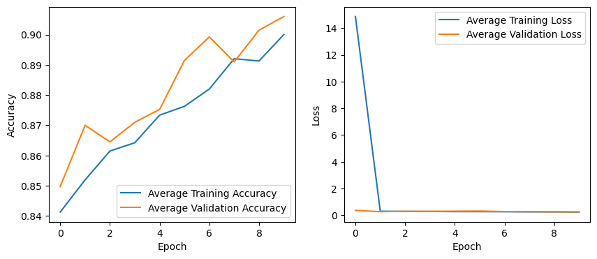

```python
# Calculate average accuracy and loss across folds
avg_accuracy = np.mean([h.history['accuracy'] for h in model2B_fold_histories], axis=0)
avg_val_accuracy = np.mean([h.history['val_accuracy'] for h in model2B_fold_histories], axis=0)
avg_loss = np.mean([h.history['loss'] for h in model2B_fold_histories], axis=0)
avg_val_loss = np.mean([h.history['val_loss'] for h in model2B_fold_histories], axis=0)

# Plot the average curves
plt.figure(figsize=(10, 4))
plt.subplot(1, 2, 1)
plt.plot(avg_accuracy, label='Average Training Accuracy')
plt.plot(avg_val_accuracy, label='Average Validation Accuracy')
plt.xlabel('Epoch')
plt.ylabel('Accuracy')
plt.legend()

plt.subplot(1, 2, 2)
plt.plot(avg_loss, label='Average Training Loss')
plt.plot(avg_val_loss, label='Average Validation Loss')
plt.xlabel('Epoch')
plt.ylabel('Loss')
plt.legend()
plt.show()

# Code credit to us
```

> [1.5 points] Visualize the final results of all the CNNs and interpret/compare the performances. Use proper statistics as appropriate, especially for comparing models.

```python
import pandas as pd

data = {
    "Model 1A": model1a_fold_f1_scores,
    "Model 1B": model1b_fold_f1_scores,
    "Model 2A": model2A_fold_f1_scores,
    "Model 2B": model2B_fold_f1_scores
}
f1df = pd.DataFrame(data)

# Descriptive statistics
print(f1df.describe())
```

```
        Model 1A   Model 1B   Model 2A   Model 2B
count  10.000000  10.000000  10.000000  10.000000
mean    0.913226   0.908246   0.875717   0.894453
std     0.048684   0.021961   0.064661   0.090634
min     0.819484   0.866310   0.769679   0.690096
25%     0.913889   0.896033   0.831862   0.857469
50%     0.922261   0.915026   0.872530   0.918707
75%     0.944732   0.922047   0.914375   0.964738
max     0.972973   0.935000   0.966581   0.977556
```

```python
# Paired t-test between Model 1A and Model 2B
from scipy import stats
t_statistic, p_value = stats.ttest_rel(f1df["Model 1A"], f1df["Model 2B"])
print(f"t-statistic: {t_statistic}, p-value: {p_value}")
```

```
t-statistic: 0.9134863573197252, p-value: 0.3848049873612659
```

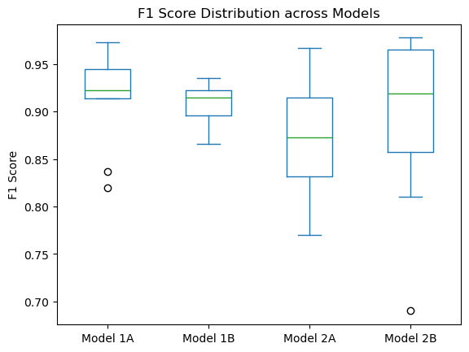

```python
import matplotlib.pyplot as plt

# Create the box plot
f1df.plot(kind="box", title="F1 Score Distribution across Models")
plt.ylabel("F1 Score")
plt.show()
```

As we noted before, model 1B exhibits the least variability in performance, as evident from its smaller box size. This suggests that its performance is more consistent across different folds of the data. model 2B shows the most variability, with a larger box and more spread-out data points. This could indicate that its performance is more sensitive to variations in the training data. And for models 1A and 2A, these models fall somewhere in between, with moderate variability in their F1 scores.

> [1 points] Compare the performance of your convolutional network to a standard multi-layer perceptron (MLP) using the receiver operating characteristic and area under the curve. Use proper statistical comparison techniques.

```python
import tensorflow as tf
from tensorflow.keras.models import Model
from tensorflow.keras.layers import Input, Flatten, Dense, Dropout
from sklearn.metrics import roc_curve, roc_auc_score

# Define the MLP model
input_layer = Input(shape=(h, w, l))
x = Flatten()(input_layer)
x = Dense(128, activation='relu')(x)
x = Dense(64, activation='relu')(x)
x = Dense(32, activation='relu')(x)
output_layer = Dense(1, activation='sigmoid')(x)
mlp = Model(inputs=input_layer, outputs=output_layer)

# Compile the MLP
mlp.compile(optimizer='adam', loss='binary_crossentropy', metrics=['accuracy'])

# Lists to store metrics for each fold
model1a_fold_aucs = []
model1a_fold_fprs = []
model1a_fold_tprs = []
mlp_fold_aucs = []
mlp_fold_fprs = []
mlp_fold_tprs = []

# Cross-validation loop
for fold, (ds_train, ds_test) in enumerate(zip(train_datasets, test_datasets)):
    # Train the MLP
    history = mlp.fit(ds_train, epochs=10, validation_data=ds_test, verbose=1)

    # Predict probabilities on the test set
    y_pred_proba = mlp.predict(ds_test).ravel()
    y_test = tf.concat([y for x, y in ds_test], axis=0).numpy()

    # Calculate ROC curve and AUC for MLP
    fpr, tpr, thresholds = roc_curve(y_test, y_pred_proba)
    auc = roc_auc_score(y_test, y_pred_proba)

    # Store AUC, FPR, and TPR for MLP in each fold
    mlp_fold_aucs.append(auc)
    mlp_fold_fprs.append(fpr)
    mlp_fold_tprs.append(tpr)
```

```python
# Extract information (AUCS) from Model 1A histories

for fold, history in enumerate(model1a_fold_histories):
    # Access validation data for the fold
    ds_test = test_datasets[fold]

    # Get predicted probabilities
    y_pred_proba = model1a.predict(ds_test).ravel()

    # Get true labels
    y_test = tf.concat([y for x, y in ds_test], axis=0).numpy()

    # Calculate ROC curve and AUC for Model 1A
    fpr, tpr, thresholds = roc_curve(y_test, y_pred_proba)
    auc = roc_auc_score(y_test, y_pred_proba)

    # Store AUC, FPR, and TPR for Model 1A in each fold
    model1a_fold_aucs.append(auc)
    model1a_fold_fprs.append(fpr)
    model1a_fold_tprs.append(tpr)
```

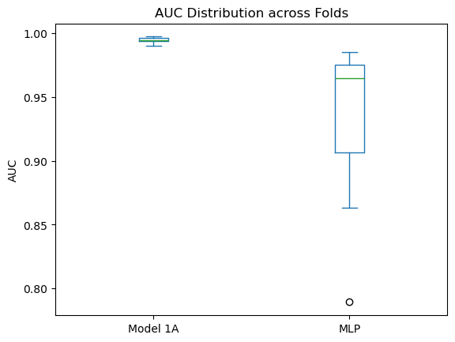

```python
import matplotlib.pyplot as plt
import pandas as pd

data = {"Model 1A": model1a_fold_aucs, "MLP": mlp_fold_aucs}
df = pd.DataFrame(data)

df.plot(kind="box", title="AUC Distribution across Folds")
plt.ylabel("AUC")
plt.show()
```

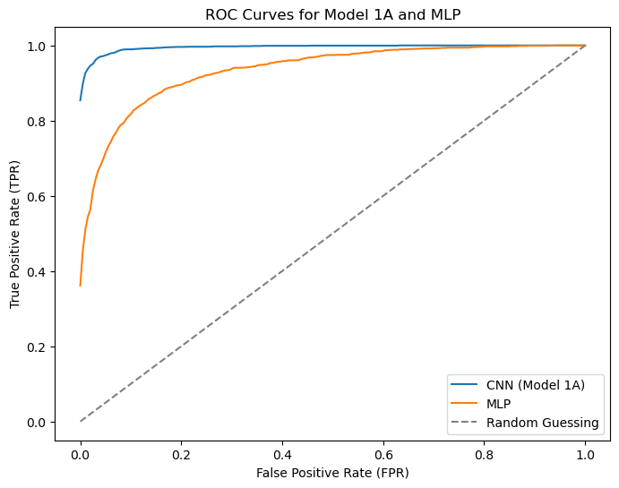

```python
import matplotlib.pyplot as plt
import numpy as np
from scipy.interpolate import interp1d

# Common thresholds for interpolation
common_thresholds = np.linspace(0, 1, 200)

# Interpolate ROC curves and calculate mean FPR/TPR for Model 1A
interp_tprs = []
for fpr, tpr in zip(model1a_fold_fprs, model1a_fold_tprs):
    interp_tpr = interp1d(fpr, tpr)(common_thresholds)
    interp_tprs.append(interp_tpr)
mean_tpr_cnn = np.mean(interp_tprs, axis=0)
mean_fpr_cnn = common_thresholds

# Interpolate ROC curves and calculate mean FPR/TPR for MLP (similar to Model 1A)
interp_tprs_mlp = []
for fpr, tpr in zip(mlp_fold_fprs, mlp_fold_tprs):
    interp_tpr = interp1d(fpr, tpr)(common_thresholds)
    interp_tprs_mlp.append(interp_tpr)
mean_tpr_mlp = np.mean(interp_tprs_mlp, axis=0)
mean_fpr_mlp = common_thresholds  # Using the same common thresholds

# Plot the ROC curves
plt.figure(figsize=(8, 6))
plt.plot(mean_fpr_cnn, mean_tpr_cnn, label='CNN (Model 1A)')
plt.plot(mean_fpr_mlp, mean_tpr_mlp, label='MLP')

# Add diagonal line representing random guessing
plt.plot([0, 1], [0, 1], linestyle='--', color='gray', label='Random Guessing')

# Add axis labels and title
plt.xlabel('False Positive Rate (FPR)')
plt.ylabel('True Positive Rate (TPR)')
plt.title('ROC Curves for Model 1A and MLP')

# Add legend
plt.legend()

plt.show()
```

```python
from scipy.stats import mannwhitneyu

u_statistic, p_value = mannwhitneyu(model1a_fold_aucs, mlp_fold_aucs)

print(f"Mann-Whitney U statistic: {u_statistic}, p-value: {p_value}")
```

```
Mann-Whitney U statistic: 100.0, p-value: 0.00018267179110955002
```

The ROC curve for Model 1A is positioned closer to the top-left corner of the plot compared to the MLP curve. This indicates that for any given false positive rate (FPR), Model 1A achieves a higher true positive rate (TPR). In other words, the CNN is better at correctly classifying positive instances without incorrectly classifying negative instances as positive. The ROC curve for the MLP is further away from the top-left corner and closer to the diagonal dashed line representing random guessing. This suggests that the MLP has lower discriminatory power compared to the CNN.

While not directly visualized on the plot, we can recall that the AUC represents the area under the ROC curve. A higher AUC indicates better overall performance; based on the positions of the curves, we can infer that Model 1A likely has a higher AUC than the MLP.

So, based on the ROC curves and the previous statistical analysis (Mann-Whitney U test), we have strong evidence to conclude that: **Model 1A (CNN) outperforms the MLP for our classification task**. The CNN demonstrates better discriminatory power and achieves a more favorable trade-off between true positive rate and false positive rate. The difference in performance is statistically significant; the low p-value from the Mann-Whitney U test supports this conclusion. However, it is important to note that the MLP was significantly faster than model 1A, as it only took around 3 minutes to run, compared to 30 minutes for model 1A.

## Exceptional Work (1 points total)

Now let's make a simple ensemble learn using multiple base CNN models. Our base model will consist of convolutional layers with ReLU activation, max pooling layers, flattening, a dense layer with ReLU activation, dropout, and a final dense layer with sigmoid activation for binary classification. At the end of training, we will print out the ensemble accuracy, which will print the accuracy of all of the trained base models.

```python
from tensorflow.keras.models import Sequential
from tensorflow.keras.layers import Conv2D, MaxPooling2D, Flatten, Dense, Dropout

# Define base CNN models
def create_base_model(input_shape):
    model = Sequential([
        Conv2D(32, (3, 3), activation='relu', input_shape=input_shape),
        MaxPooling2D((2, 2)),
        Conv2D(64, (3, 3), activation='relu'),
        MaxPooling2D((2, 2)),
        Conv2D(128, (3, 3), activation='relu'),
        MaxPooling2D((2, 2)),
        Flatten(),
        Dense(128, activation='relu'),
        Dropout(0.5),
        Dense(1, activation='sigmoid')
    ])
    return model

# Train base models
base_models = []
base_models_history = []  # To store training history

for train_dataset in train_datasets:
    base_model = create_base_model((h, w, 1))
    base_model.compile(optimizer='adam', loss='binary_crossentropy', metrics=['accuracy'])
    base_model.fit(train_dataset, epochs=10)
    base_models.append(base_model)
    base_models_history.append(history)

# Combine predictions
def ensemble_predict(base_models, X):
    predictions = []
    for base_model in base_models:
        prediction = base_model.predict(X)
        predictions.append(prediction)
    return np.mean(predictions, axis=0)  # Ensemble by averaging predictions

# Evaluate ensemble performance
def evaluate_ensemble(base_models, test_datasets):
    accuracies = []
    for base_model, test_dataset in zip(base_models, test_datasets):
        _, accuracy = base_model.evaluate(test_dataset)
        accuracies.append(accuracy)
    return np.mean(accuracies)

ensemble_accuracy = evaluate_ensemble(base_models, test_datasets)
print("Ensemble Accuracy:", ensemble_accuracy)
```

```
Ensemble Accuracy: 0.8930000007152558
```

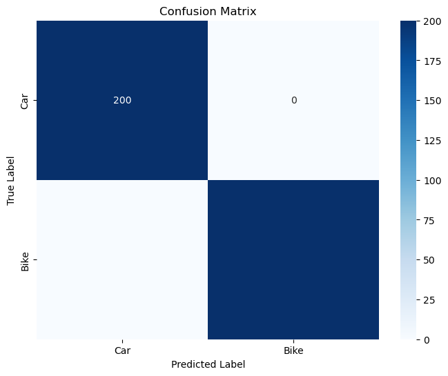

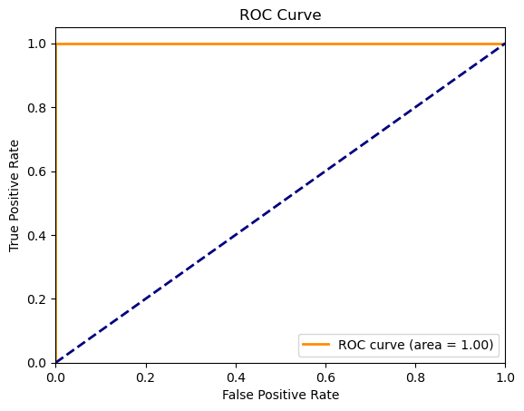

[figure not shown]

```python
from sklearn.metrics import confusion_matrix, roc_curve, auc, precision_recall_curve

# Plot Training History
def plot_training_history(base_models_history):
    plt.figure(figsize=(12, 6))
    for i, history in enumerate(base_models_history):
        plt.subplot(1, len(base_models_history), i+1)
        plt.plot(history.history['accuracy'], label='Training Accuracy')
        plt.plot(history.history['loss'], label='Training Loss')
        plt.title('Model {}'.format(i+1))
        plt.xlabel('Epoch')
        plt.ylabel('Accuracy/Loss')
        plt.legend()
    plt.tight_layout()
    plt.show()

# Confusion Matrix
def plot_confusion_matrix(y_true, y_pred, labels):
    cm = confusion_matrix(y_true, y_pred)
    plt.figure(figsize=(8, 6))
    sns.heatmap(cm, annot=True, fmt='d', cmap='Blues', xticklabels=labels, yticklabels=labels)
    plt.xlabel('Predicted Label')
    plt.ylabel('True Label')
    plt.title('Confusion Matrix')
    plt.show()

# ROC Curve and AUC
def plot_roc_curve(y_true, y_pred):
    fpr, tpr, _ = roc_curve(y_true, y_pred)
    roc_auc = auc(fpr, tpr)
    plt.figure()
    plt.plot(fpr, tpr, color='darkorange', lw=2, label='ROC curve (area = %0.2f)' % roc_auc)
    plt.plot([0, 1], [0, 1], color='navy', lw=2, linestyle='--')
    plt.xlim([0.0, 1.0])
    plt.ylim([0.0, 1.05])
    plt.xlabel('False Positive Rate')
    plt.ylabel('True Positive Rate')
    plt.title('ROC Curve')
    plt.legend(loc='lower right')
    plt.show()


y_pred = ensemble_predict(base_models, X_test)
plot_confusion_matrix(y_test, np.round(y_pred), ['Car', 'Bike'])
plot_roc_curve(y_test, y_pred)
plot_training_history(base_models_history)
```